# StackOverflow Tags Network

2022-07-14

## A network of tags used in StackOverflow: dataset

Our dataset is structured in two files:

- *stack_network_nodes.csv* is a csv file containing information about the nodes of the network. Each node is associated to a specific tag.
- *stack_network_links.csv* is a csv file containing information about the links of the network. An edge between two nodes means that the those tags can be found in the same post. The weight of the edge is a measure of how often those tags are used together.

## The network

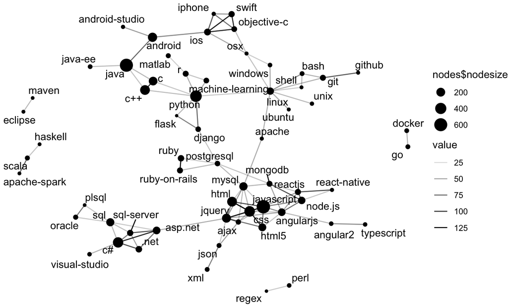

## Centrality measures

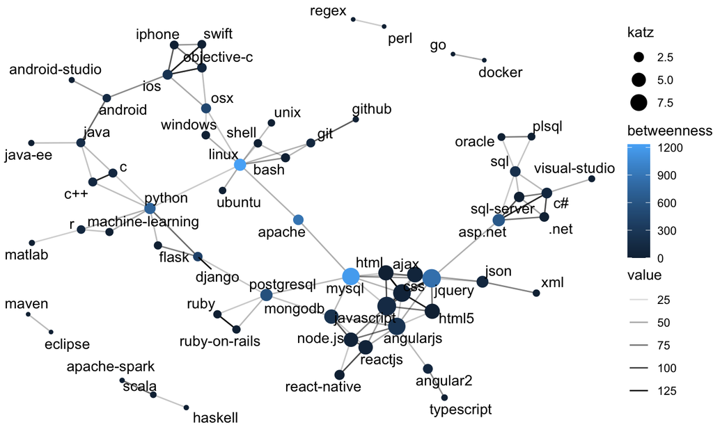

## Compare degree centrality, Katz centrality and betweenness

We compare the different centrality measures:

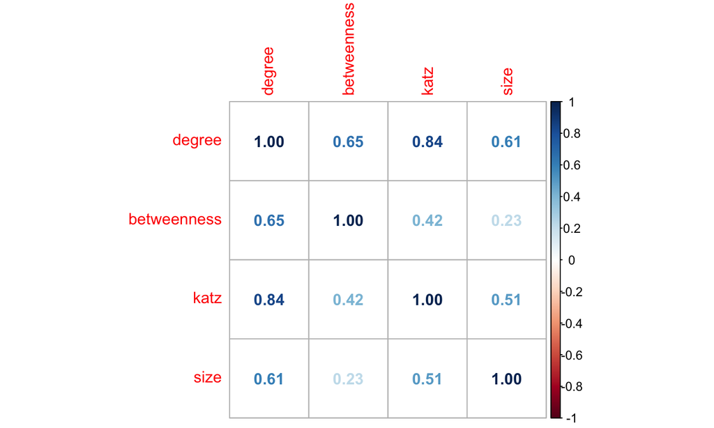

## Highest betweenness score

What technologies are more important to connect different parts of the graph?

|  | betweenness |
| --- | --- |
| linux | 1233.8571 |
| mysql | 1198.2143 |
| apache | 881.1905 |
| jquery | 847.4048 |
| python | 729.3333 |

## Comparison with the expected flow

An alternative way of evaluating how meaningful is a link between two nodes is two compare flow of the network with the flow that can be found in a network with the same nodes, where the links are distributed randomly.

Top 5 Entries

| from | to | weight | tag.x | tag.y |
| --- | --- | --- | --- | --- |
| 60 | 61 | 175.1320 | regex | perl |
| 40 | 57 | 175.0420 | maven | eclipse |
| 46 | 52 | 174.9723 | docker | go |
| 19 | 28 | 144.5492 | apache-spark | scala |
| 3 | 4 | 137.9165 | ruby | ruby-on-rails |

These result were expected…

- “**Perl** gained widespread popularity […], in part due to its powerful **regular expression** and string parsing abilities” [Source: Wikipedia]
- **Docker** is written in **Go**
- **Apache-Spark** is written in **Scala**

Bottom 5 Entries

| from | to | weight | tag.x | tag.y |
| --- | --- | --- | --- | --- |
| 2 | 5 | -8.104616 | css | ios |
| 5 | 13 | -7.831358 | ios | javascript |
| 5 | 14 | -7.625566 | ios | jquery |
| 2 | 42 | -7.418065 | css | linux |
| 2 | 11 | -7.360218 | css | c# |

## Community detection

We can ask ourselves: is it possible to identify groups of tags that represent similar technologies?

We try to answer this question using **community detection**, a technique that identifies sets of tags that are more strongly connected to each other.

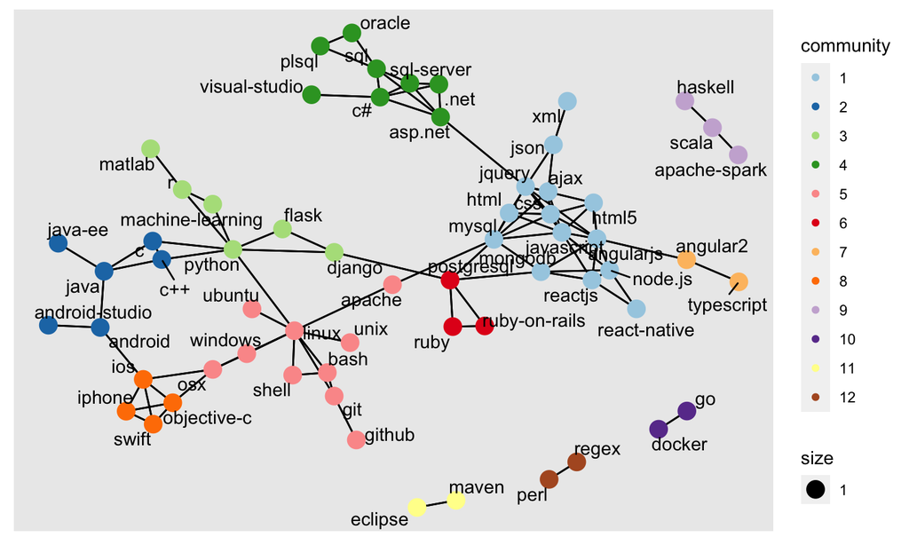

## Some examples…

Group 7 is composed by only two members, **Angular2** and **TypeScript**: turns out that the former is a language based on latter!

| name | group |
| --- | --- |
| angular2 | 7 |
| typescript | 7 |

The last example is Group 8, which comprehends technologies are used for the development of Apple products: **Objective-C** has been for a long time the primary programming language for writing software for **OS X** and **iOS**, while more recently **Swift** was introduced as an improvement of Objective-C.

| name | group |
| --- | --- |
| ios | 8 |
| swift | 8 |
| objective-c | 8 |
| iphone | 8 |

## Hierarchical Clustering

A more advanced way of grouping together tags based on their domain is **Hierarchical Clustering**, which establishes a hierarchy of nodes based on the similarity score between them.

For example:

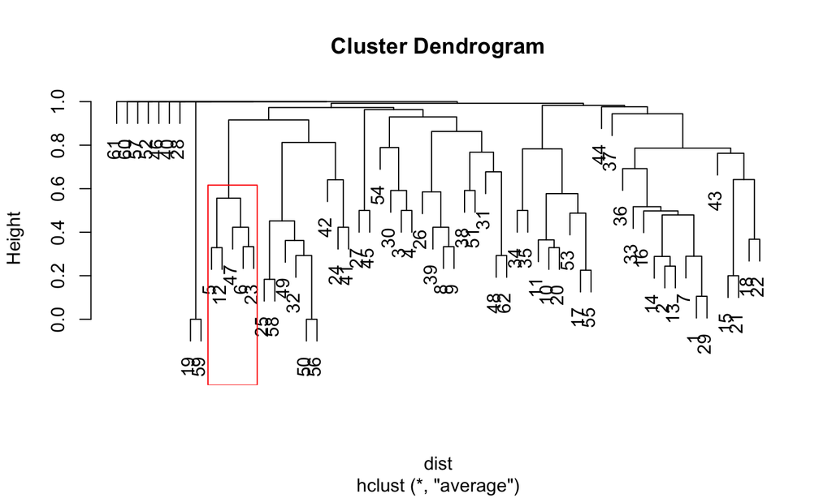

… But doesn’t always work:

- 16 is MySQL, 54 is PostgreSQL

## Most interdisciplinary (or versatile)

We use measures of **heterogeneity** to evaluate what tags are more versatile.

The table shows the 5 most interdisciplinary tags according to the **Shannon entropy**:

| tag | shannon_id | simpson_id | rao_id |
| --- | --- | --- | --- |
| linux | 3.144702 | 0.8848556 | 0.4674045 |
| jquery | 3.089295 | 0.8767419 | 0.4933819 |
| javascript | 3.074007 | 0.8741313 | 0.4989414 |
| mysql | 2.983625 | 0.8720451 | 0.6062787 |
| angularjs | 2.955624 | 0.8669772 | 0.5839425 |

Interestingly, “a web analysis indicates that [**jQuery**] is the most widely deployed **JavaScript** library by a large margin” (source: Wikipedia)

**AngularJS** is front-end web framework based on **JavaScript.**

## Least interdisciplinary (or versatile)

The 5 least interdisciplinary tags are the following:

| tag | shannon_id | simpson_id | rao_id |
| --- | --- | --- | --- |
| github | 0 | 0 | 0 |
| xml | 0 | 0 | 0 |
| java-ee | 0 | 0 | 0 |
| maven | 0 | 0 | 0 |
| typescript | 0 | 0 | 0 |

This data make sense *according to the data we have*, because those nodes find themselves in the outskirts of the graph…

## Another look to communities…

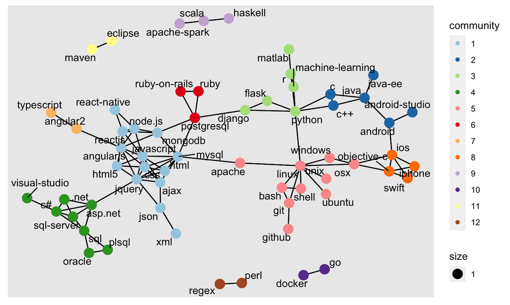

## Comparison of heterogeneity measures

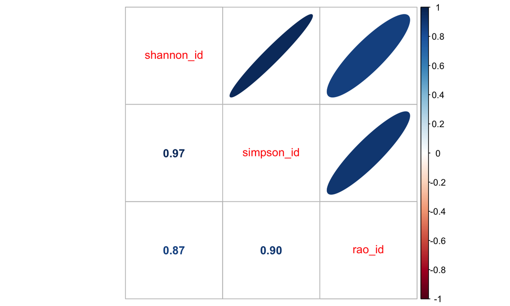

## Conclusions

From the analysis emerged the following facts:

- Through the centrality measures, we discovered that the number of posts in which a tag appears is not strongly related to the centrality of the tag in the network,
- Languages based on **JavaScript** are extremely versatile,
- Nodes in the same community can be similar technologies, but can also be different technologies that work well together!